Research Design

# Happy Randomization

Random assignment balances groups *on average*, not in every study. Three simulations show how often a perfectly fair lottery produces groups that look different, why small groups make it worse, and how to test for balance without fooling yourself when the balance table has many rows.

Overview

## Key concepts

Why a study that randomized correctly still has to check its groups.

The argument in four claims

Randomization is fair, not perfect.

Random assignment guarantees that groups are equal **in expectation**: averaged over every possible lottery, no group is favored. Any single lottery can still deal one group the stronger students. A study that randomized correctly can be unlucky. When the groups turn out comparable we call it **happy randomization**.

A 5% test raises a false alarm 5% of the time, by design.

When the groups really are equivalent in the population, a t-test at α = 0.05 will still call one contrast in twenty "significant." That is what the 0.05 means.

More tests, more false alarms.

Five study groups produce 10 pairwise contrasts, and a balance table with 20 covariates produces 20 tests. The chance that *at least one* of them comes out significant grows quickly. When the tests are an omnibus check of equivalence across many covariates, the decision rule for the whole table has to be adjusted: divide α by the number of tests (Bonferroni), or run one joint test.

Big samples shrink imbalances, not false alarms.

As groups grow, their means converge on each other and the **size** of any chance imbalance falls. The **false-alarm rate** of each test stays at 5% at every sample size. Small studies are the ones that get substantively unbalanced groups, which is why they often stratify the lottery instead of relying on luck.

### Where the question comes from

The study described in the Chapter 1 reading randomizes *blocks* of students (classrooms) rather than individual students, and it has only a handful of blocks per study group. Instead of a single lottery, it assigns blocks in **tranches**: rank the blocks by prior academic performance, take the top tranche and randomly give one block to each study group, then do the same with the next tranche, and so on down the list.

Why go to the trouble? If assignment is random, shouldn't the groups come out balanced anyway? The simulations below answer that question.

Section one

## Group differences after random assignment

Five study groups of ten blocks each: how often a fair lottery produces groups that differ, and what changes as the groups grow.

### The setup

A district has 50 classroom blocks. For each block we know its average prior-year test score. Across all 50 blocks the scores average 49.8 with a standard deviation of 9.7. We randomly assign 10 blocks to each of 5 study groups, and nothing about the lottery depends on the scores.

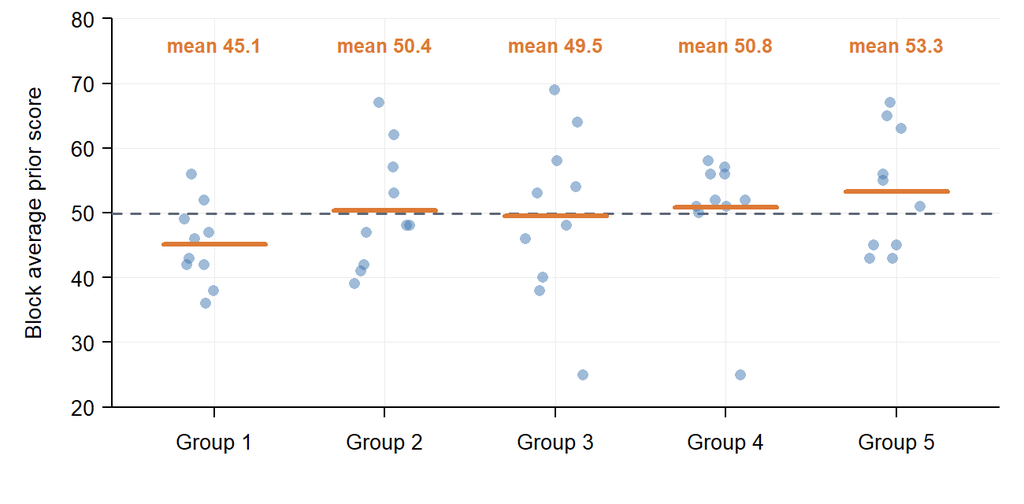

One random assignment of 50 blocks to 5 groups. Dots are blocks; orange bars are group means; the dashed line is the mean of all 50 blocks.

Group means after one lottery

| Study group | Mean prior score | Gap from overall mean |
| --- | --- | --- |
| Group 1 | 45.1 | -4.7 |
| Group 2 | 50.4 | 0.6 |
| Group 3 | 49.5 | -0.3 |
| Group 4 | 50.8 | 1.0 |
| Group 5 | 53.3 | 3.5 |

Same population, same lottery rules, yet the group means span 8.2 points, from 45.1 to 53.3.

Why a group that is too high or too low matters

Suppose Group 1 happened to be the **control group**. It starts 4.7 points below the average block, about 0.49 standard deviations. Every treatment group would then look better than the control before the program did anything, and the study would report that head start as a program effect. If the unlucky draw had put the strongest blocks in the control group instead, a real effect could be hidden. In a post-test-only design, the comparison groups have to be equivalent at baseline, because the control group is the counterfactual.

Is a gap this size unusual, or is it what fair lotteries normally produce? To find out, compare every group with every other group.

### How many contrasts?

With *g* groups, the number of distinct pairs is

number of contrasts = *g*(*g* − 1) / 2

Each group is paired with the *g* − 1 others, and dividing by 2 removes duplicates (Group 1 vs Group 2 is the same contrast as Group 2 vs Group 1). Five groups give 5 × 4 / 2 = 10 contrasts. The count grows much faster than the number of groups:

Contrasts grow with the square of the number of groups

| Groups | Pairwise contrasts | Contrasts expected to be significant by chance at α = .05 |
| --- | --- | --- |
| 2 | 1 | 0.05 |
| 3 | 3 | 0.15 |
| 4 | 6 | 0.30 |
| 5 | 10 | 0.50 |
| 6 | 15 | 0.75 |
| 10 | 45 | 2.25 |

### Testing all ten contrasts

The 10 contrasts are easiest to see as a picture. Put the five groups at the corners of a pentagon and draw a line between every pair: the five sides plus the five-pointed star inside (a pentagram) are exactly the 10 contrasts. Each line is one t-test of the difference in mean prior scores between the two groups it connects.

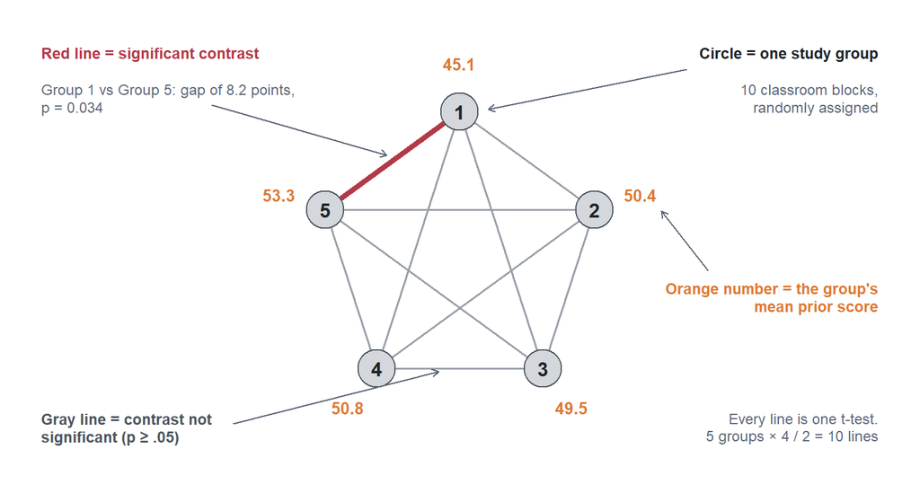

The lottery shown above, drawn as a contrast diagram. Each of the 10 lines is a two-sample t-test between the groups at its ends.

The same 10 contrasts as a table

| Contrast | Difference in means | p-value |
| --- | --- | --- |
| Group 1 vs Group 2 | -5.3 | 0.152 |
| Group 1 vs Group 3 | -4.4 | 0.353 |
| Group 1 vs Group 4 | -5.7 | 0.132 |
| Group 1 vs Group 5 | -8.2 | 0.034 |
| Group 2 vs Group 3 | 0.9 | 0.861 |
| Group 2 vs Group 4 | -0.4 | 0.925 |
| Group 2 vs Group 5 | -2.9 | 0.494 |
| Group 3 vs Group 4 | -1.3 | 0.802 |
| Group 3 vs Group 5 | -3.8 | 0.465 |
| Group 4 vs Group 5 | -2.5 | 0.560 |

One contrast, Group 1 vs Group 5, is significant at the 5% level (p = 0.034). Group 1 drew mostly low-scoring blocks and Group 5 drew mostly high-scoring ones. Nothing went wrong: every group came from the same 50 blocks through a fair process. That is simply what happens in some lotteries. (We chose this lottery because it contains a significant contrast, so the example has something to show. The next step reports how often that happens.)

### Repeat the lottery 5,000 times

To see what is typical, we rerun the random assignment 5,000 times on the same 50 blocks and count how many of the 10 contrasts come out significant each time.

0.47 significant contrasts per lottery, on average (expected: 10 × 0.05 = 0.50)

28% of lotteries show at least one significant contrast

72% of lotteries pass all 10 tests

Here are the first 100 of those lotteries, each drawn as its own contrast diagram. In 28 of the 100, at least one line is red (shaded panels).

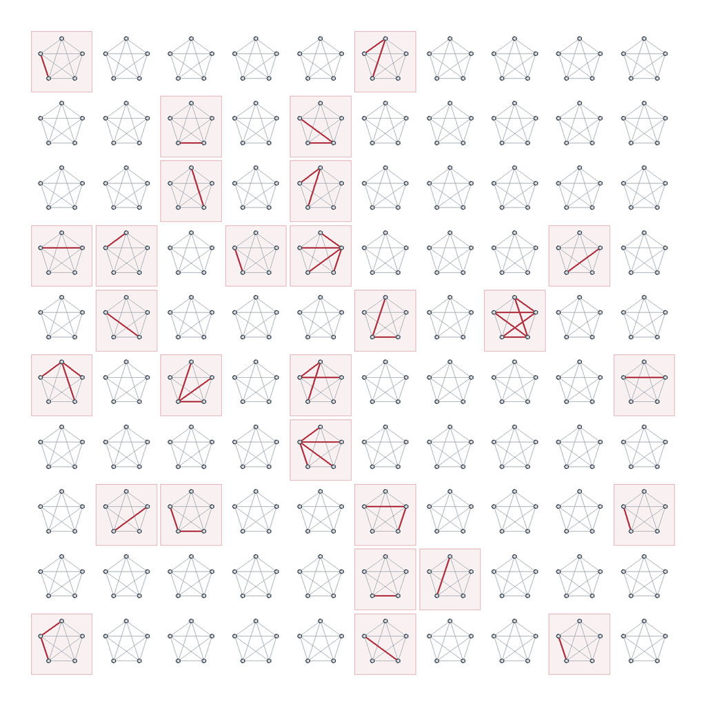

100 random assignments of the same 50 blocks. Red lines are contrasts significant at p < .05; shaded panels contain at least one. Every one of these lotteries was fair.

Significant contrasts per lottery, 5,000 lotteries

| Number significant (of 10) | Share of lotteries |
| --- | --- |
| 0 | 72.2% |
| 1 | 15.0% |
| 2 | 7.9% |
| 3 or more | 4.9% |

The average of 0.47 is what the arithmetic predicts: 10 tests, each with a 5% chance of a false alarm, gives 0.5 expected false alarms. Put another way, **roughly 28% of perfectly valid randomizations would "fail" a balance check that uses p < .05 for each contrast.**

Why 28% and not 40%?

If the 10 tests were independent, the chance of at least one false alarm would be 1 − 0.95<sup>10</sup> = 40%. They are not independent: every group appears in four contrasts, so one unusual group tends to set off several tests at once (note the lotteries with 2 or more). Overlapping tests produce fewer lotteries with *any* alarm, but the *average* number of alarms is still 0.5.

**R code: one lottery and 5,000 repeats**

```r
# ---- shared simulation functions (shown again in the code boxes below) ---------

# Random assignment: shuffle equal numbers of each group label across the blocks.
assign_groups <- function(n.blocks, n.groups = 5) {
  sample(rep(paste("Group", 1:n.groups), length.out = n.blocks))
}

# Every pairwise t-test between groups: n(n - 1) / 2 contrasts.
pairwise_tests <- function(y, group) {
  pairs <- combn(sort(unique(group)), 2)
  data.frame(
    g1      = pairs[1, ],
    g2      = pairs[2, ],
    diff    = apply(pairs, 2, function(p) mean(y[group == p[1]]) - mean(y[group == p[2]])),
    p.value = apply(pairs, 2, function(p) t.test(y[group == p[1]], y[group == p[2]])$p.value)
  )
}
# ---- Part 1: five groups of ten blocks -----------------------------------------

set.seed(2026)
blocks <- data.frame(block = 1:50, score = round(rnorm(50, mean = 50, sd = 10)))

# One randomization to look at closely. We search for the first seed whose draw
# contains exactly one significant contrast, so the example shows a false alarm.
seed <- 1
repeat {
  set.seed(seed)
  blocks$group <- assign_groups(50)
  tests <- pairwise_tests(blocks$score, blocks$group)
  if (sum(tests$p.value < 0.05) == 1) break
  seed <- seed + 1
}
group.means <- tapply(blocks$score, blocks$group, mean)
sig.row     <- tests[tests$p.value < 0.05, ]

# The same randomization repeated 5,000 times.
set.seed(1)
n.sig <- replicate(5000, {
  group <- assign_groups(50)
  sum(pairwise_tests(blocks$score, group)$p.value < 0.05)
})
# Keep the full results of the first 100 lotteries to draw as a grid.
set.seed(100)
grid.tests <- replicate(100, simplify = FALSE,
                        pairwise_tests(blocks$score, assign_groups(50)))
grid.any   <- sapply(grid.tests, function(t) any(t$p.value < 0.05))

avg.sig  <- mean(n.sig)
any.sig  <- mean(n.sig > 0)
dist.sig <- table(factor(pmin(n.sig, 3), levels = 0:3)) / length(n.sig)
```

### What changes when the groups get bigger

Now keep the design (5 groups, random assignment) but vary the number of blocks per group from 10 to 1,000. For each size we draw a population of blocks with mean 50 and standard deviation 10, run the lottery 1,000 times, and record two things: how far apart the group means land, and whether any of the 10 contrasts is significant.

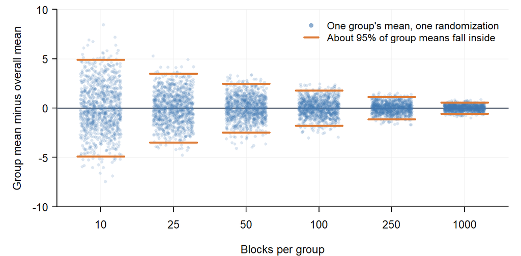

Each dot is one group's mean (minus the overall mean) from one of 200 lotteries. The spread shrinks in proportion to 1 / √*n*.

Five groups, 1,000 lotteries at each size

| Blocks per group | Standard error of a group mean | Average gap, highest minus lowest group mean | Lotteries with at least one significant contrast |
| --- | --- | --- | --- |
| 10 | 2.74 | 6.33 | 29% |
| 25 | 1.95 | 4.54 | 28% |
| 50 | 1.38 | 3.16 | 29% |
| 100 | 1.00 | 2.33 | 28% |
| 250 | 0.64 | 1.44 | 28% |
| 1000 | 0.31 | 0.73 | 28% |

Read the two right-hand columns together:

- **The gap shrinks.** With 10 blocks per group, the best and worst groups differ by about 6.3 points on average, which is 0.63 standard deviations, large enough to swamp a modest program effect. With 1,000 blocks per group the gap is 0.73 points. This is the law of large numbers at work: every group mean converges on the population mean, so they converge on each other.
- **The false-alarm rate does not.** About 28% of lotteries show a significant contrast at every size. The t-test measures differences relative to their standard error, and the standard error shrinks just as fast as the gap does.

The lesson for small studies

Large samples do not make the balance test easier to pass. They make the imbalances you *do* get too small to matter. In a study with only 10 blocks per group, a chance gap of several points is common, and the outcome comparison inherits it. That is why the study in the reading assigned blocks in tranches: **stratified (blocked) randomization** forces each group to get one block from each performance level, so balance on prior scores is guaranteed by construction rather than left to luck.

**R code: larger groups**

```r
# ---- Part 1b: the same design with larger groups -------------------------------

sizes <- c(10, 25, 50, 100, 250, 1000)          # blocks per group

converge <- lapply(sizes, function(n) {
  set.seed(n)
  score <- rnorm(5 * n, mean = 50, sd = 10)      # a population of 5n blocks
  sims <- replicate(1000, {
    group <- assign_groups(5 * n)
    means <- tapply(score, group, mean) - mean(score)
    c(gap = max(means) - min(means),
      any.sig = any(pairwise_tests(score, group)$p.value < 0.05),
      means)
  })
  list(n = n, gap = mean(sims["gap", ]), any.sig = mean(sims["any.sig", ]),
       se = sd(score) / sqrt(n),
       deviations = as.vector(sims[-(1:2), 1:200]))  # group means from 200 draws
})
conv <- do.call(rbind, lapply(converge, function(x)
  data.frame(n = x$n, gap = x$gap, se = x$se, any.sig = x$any.sig)))
```

Section two

## Bonferroni corrections for balance tables

Two groups, many covariates. A balance table is a set of tests run together, and its decision rule has to account for how many there are.

### A typical balance table

A study of a tutoring program randomly assigns 200 students: 100 to treatment and 100 to control. Before the program starts, it measures baseline attributes that could affect test scores, to check balance and to use as controls later. Published studies report this check as a balance table: one row per attribute, the mean in each group, the difference, and a test of that difference. Here is one for five of the attributes.

Table 1. Balance between treatment and control students at baseline

| Student characteristic | Treatment (N = 100) | Control (N = 100) | Difference | p-value |
| --- | --- | --- | --- | --- |
| Mother's education (years) | 12.9 | 13.1 | -0.2 | 0.618 |
| Family income ($1,000s) | 68.6 | 67.3 | 1.3 | 0.824 |
| Black = 1 | 0.12 | 0.19 | -0.07 | 0.173 |
| Free or reduced-price lunch = 1 | 0.52 | 0.37 | 0.15 | 0.033* |
| Prior math score | 49.5 | 50.8 | -1.3 | 0.326 |
| Joint F-test of all five characteristics, F(5, 194) = 1.59 |  |  |  | 0.166 |

*Source:* simulated data.  
* Significant at the 5 percent level.  
The joint F-test regresses the treatment indicator on all five characteristics and tests whether they jointly predict assignment.

Read the way most balance tables are read, the star says the groups differ on free or reduced-price lunch eligibility, so the randomization looks unhappy. But this table runs five tests at once. Even if the lottery worked perfectly, the chance that at least one of five independent tests comes out significant at the 5% level is

1 − (1 − 0.05)<sup>5</sup> = 1 − 0.95<sup>5</sup> = 0.23

So a "starred" row shows up in nearly a quarter of balance tables like this one when nothing is wrong. The question a balance table is meant to answer is about the whole table (are the groups equivalent?), so the error rate has to be controlled for the whole table, not row by row.

### The Bonferroni correction

The Bonferroni correction keeps the overall false-alarm rate at α by dividing it among the *k* tests:

*α*<sub>adjusted</sub> = *α* / *k* = 0.05 / 5 = 0.01

A row now counts as a meaningful imbalance only if its p-value is below 0.01. In Table 1 the smallest p-value is 0.033, which is above 0.01, so the table as a whole gives no evidence that the groups differ. The star was a false alarm of the kind we should expect to see in about one row out of every twenty.

The joint F-test in the last row of Table 1 reaches the same conclusion in a single step. Instead of five tests, it asks one question: do the five characteristics, taken together, predict which students were assigned to treatment? With p = 0.166 (above 0.05), they do not, so there is no evidence of imbalance. Because it is one test, it is compared with the ordinary α = 0.05, with no correction needed.

Where the correction applies

Bonferroni is a rule for an **omnibus test**: many tests run together to answer one yes-or-no question, such as "are these groups equivalent at baseline?" It is not needed for the group contrasts in Section one, where each difference between study groups matters in its own right. A control group that started out low is a problem whatever the other contrasts show.

### Simulating 1,000 balance tables

How often does the unadjusted rule (any row with p < .05) flag a perfectly randomized study, and how does that change as the table gets longer? We simulate 20 baseline attributes, added to the balance table in this order:

Baseline covariates

| Covariates 1–10 | Covariates 11–20 |
| --- | --- |
| 1. Mother's education (years) | 11. Prior math score |
| 2. Father's education (years) | 12. Prior reading score |
| 3. Family income ($1,000s) | 13. Age (months) |
| 4. Black (0/1) | 14. Days absent last year |
| 5. Hispanic (0/1) | 15. Household size |
| 6. Asian (0/1) | 16. Single-parent household (0/1) |
| 7. Female (0/1) | 17. Changed schools last year (0/1) |
| 8. Free or reduced-price lunch (0/1) | 18. Books at home |
| 9. English learner (0/1) | 19. Homework hours per week |
| 10. Special education (0/1) | 20. Attended preschool (0/1) |

For each covariate we run a two-sample t-test of the difference in means between treatment and control. The standard rule is: if any test is significant at p < .05, the groups are "not equivalent." We simulate 1,000 separate studies. Each one draws a fresh set of 200 students and a fresh lottery, so every difference is due to chance alone. A balance table with *k* rows uses the first *k* covariates.

We also apply two corrected rules:

- **Bonferroni:** a row counts as significant only if p < 0.05 / *k*. With 10 covariates the threshold is 0.005.
- **Joint F-test:** regress the treatment indicator on all *k* covariates and test whether they jointly predict assignment. One omnibus test, one p-value, compared with 0.05.

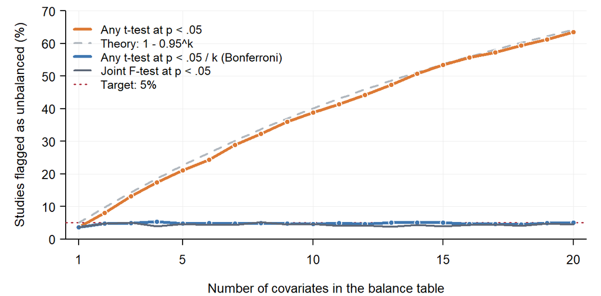

Share of 1,000 perfectly randomized studies that the balance check would declare unbalanced, by number of covariates tested.

1,000 randomized studies per row, 100 treated and 100 controls

| Covariates tested (*k*) | Studies with any difference at p < .05 | Theory: 1 − 0.95<sup>*k*</sup> | Average number of significant differences | Studies with any difference, Bonferroni (p < .05 / *k*) | Studies failing joint F-test (p < .05) |
| --- | --- | --- | --- | --- | --- |
| 1 | 3.6% | 5.0% | 0.04 | 3.6% | 3.6% |
| 2 | 8.1% | 9.8% | 0.08 | 4.8% | 4.8% |
| 3 | 13.1% | 14.3% | 0.14 | 4.9% | 5.0% |
| 4 | 17.4% | 18.5% | 0.18 | 5.3% | 4.0% |
| 5 | 21.1% | 22.6% | 0.23 | 4.8% | 4.7% |
| 6 | 24.3% | 26.5% | 0.27 | 4.9% | 4.4% |
| 7 | 28.9% | 30.2% | 0.33 | 4.8% | 4.4% |
| 8 | 32.3% | 33.7% | 0.38 | 4.9% | 5.2% |
| 9 | 36.0% | 37.0% | 0.43 | 4.8% | 4.5% |
| 10 | 38.8% | 40.1% | 0.47 | 4.7% | 4.7% |
| 11 | 41.4% | 43.1% | 0.52 | 4.9% | 4.1% |
| 12 | 44.2% | 46.0% | 0.57 | 4.7% | 4.2% |
| 13 | 47.4% | 48.7% | 0.62 | 5.1% | 3.8% |
| 14 | 50.7% | 51.2% | 0.69 | 5.0% | 4.4% |
| 15 | 53.4% | 53.7% | 0.75 | 5.1% | 3.9% |
| 16 | 55.7% | 56.0% | 0.80 | 4.6% | 4.3% |
| 17 | 57.3% | 58.2% | 0.84 | 4.6% | 4.5% |
| 18 | 59.4% | 60.3% | 0.89 | 4.5% | 4.1% |
| 19 | 61.3% | 62.3% | 0.94 | 4.9% | 4.8% |
| 20 | 63.5% | 64.2% | 0.99 | 5.1% | 4.5% |

### Reading the table

- **The unadjusted rule fails more and more valid studies.** With one covariate, a study is flagged 4% of the time, close to the nominal 5% (the gap is simulation noise). With 10 covariates, 39% of perfectly randomized studies show at least one "significant" imbalance; with 20, 64% do. Here the tests are nearly independent (the covariates are simulated independently), so the rate tracks the formula 1 − 0.95<sup>*k*</sup>.
- **The average count rises in a straight line:** about 0.05 × *k*, or one false alarm for every 20 covariates. Finding one significant row in a 20-row balance table is exactly what a successful randomization looks like.
- **Both corrected rules hold the error rate near 5%** no matter how many covariates are tested. They answer the question we actually care about: *is there evidence that the groups differ, taking the whole table into account?*

Bonferroni or joint F-test?

Bonferroni is simple and is the rule used in the lab: compare each p-value with α / *k*. It is conservative when covariates are correlated (parents' education and family income usually are), because it treats overlapping tests as separate chances to err. The joint F-test accounts for correlation automatically and gives one answer for the whole table. Either is defensible. Testing each row at 0.05 is not.

**R code for this section**

```r
# ---- Part 2: treatment vs control, 1 to 20 covariates --------------------------

# One simulated study population: n students and 20 baseline attributes.
make_students <- function(n) {
  data.frame(
    mother.educ     = rnorm(n, 13, 2.5),          # years of schooling
    father.educ     = rnorm(n, 13, 2.8),
    family.income   = rlnorm(n, log(55), 0.6),    # $1,000s
    black           = rbinom(n, 1, 0.15),
    hispanic        = rbinom(n, 1, 0.25),
    asian           = rbinom(n, 1, 0.06),
    female          = rbinom(n, 1, 0.50),
    free.lunch      = rbinom(n, 1, 0.45),
    english.learner = rbinom(n, 1, 0.10),
    special.ed      = rbinom(n, 1, 0.13),
    prior.math      = rnorm(n, 50, 10),
    prior.reading   = rnorm(n, 50, 10),
    age.months      = rnorm(n, 120, 4),
    days.absent     = rpois(n, 8),
    household.size  = 2 + rpois(n, 2),
    single.parent   = rbinom(n, 1, 0.30),
    changed.school  = rbinom(n, 1, 0.12),
    books.at.home   = rpois(n, 40),
    homework.hours  = rgamma(n, 2, 0.4),
    preschool       = rbinom(n, 1, 0.60)
  )
}

set.seed(2026)
studies <- replicate(1000, simplify = FALSE, {
  students <- make_students(200)
  treat    <- sample(rep(0:1, each = 100))       # 100 treated, 100 controls

  # one t-test per covariate
  p <- sapply(students, function(x) t.test(x[treat == 1], x[treat == 0])$p.value)

  # omnibus alternative: regress treatment on the first k covariates, joint F-test
  f.p <- sapply(1:20, function(k) {
    f <- summary(lm(treat ~ ., data = students[1:k]))$fstatistic
    pf(f[1], f[2], f[3], lower.tail = FALSE)
  })
  list(p = p, f.p = f.p)
})

P  <- t(sapply(studies, `[[`, "p"))    # 1,000 studies x 20 covariates
FP <- t(sapply(studies, `[[`, "f.p"))  # 1,000 studies x 20 joint tests

k <- 1:20
n.sig.k  <- lapply(k, function(j) rowSums(P[, 1:j, drop = FALSE] < 0.05))
n.bonf.k <- lapply(k, function(j) rowSums(P[, 1:j, drop = FALSE] < 0.05 / j))

results <- data.frame(
  k        = k,
  any.sig  = sapply(n.sig.k, function(x) mean(x > 0)),
  avg.sig  = sapply(n.sig.k, mean),
  expected = 1 - 0.95^k,
  bonf     = sapply(n.bonf.k, function(x) mean(x > 0)),
  joint.F  = colMeans(FP < 0.05)
)
# ---- One study for the demo balance table (5 covariates) -----------------------

# Search for the first seed whose table has exactly one row significant at .05
# that does not survive the Bonferroni threshold of .05 / 5 = .01.
demo.vars <- c("mother.educ", "family.income", "black", "free.lunch", "prior.math")
seed <- 1
repeat {
  set.seed(seed)
  students <- make_students(200)[demo.vars]
  treat    <- sample(rep(0:1, each = 100))
  demo <- data.frame(
    treat.mean = sapply(students, function(x) mean(x[treat == 1])),
    ctrl.mean  = sapply(students, function(x) mean(x[treat == 0])),
    p.value    = sapply(students, function(x) t.test(x[treat == 1], x[treat == 0])$p.value)
  )
  if (sum(demo$p.value < 0.05) == 1 && all(demo$p.value >= 0.01)) break
  seed <- seed + 1
}

# Joint F-test: do the five covariates together predict treatment assignment?
demo.f   <- summary(lm(treat ~ ., data = students))$fstatistic
demo.f.p <- pf(demo.f[1], demo.f[2], demo.f[3], lower.tail = FALSE)
```

Section three

## Takeaways

How to check whether a randomization was happy.

1. **Always check balance, even after random assignment.** Randomization makes the groups equal on average across all possible lotteries, not in the one lottery your study got.
2. **Count your tests before you read them.** Five groups means 10 contrasts; 20 covariates means 20 tests. At α = .05, expect about one false alarm per 20 tests.
3. **Adjust the decision rule for the whole table.** Use α / *k* (Bonferroni) or a single joint F-test. The unadjusted rule rejects most valid randomizations once the table has more than about 14 rows.
4. **Look at the size of differences, not just their significance.** In a large study a trivial difference can be significant; in a small study a substantively large difference can fail to reach significance. Report standardized differences (difference in means divided by the standard deviation) alongside p-values.
5. **Small studies should not rely on luck.** With few units per group, use stratified or blocked randomization (like the tranches in the reading) to guarantee balance on the variables that matter most.
6. **Include baseline covariates as controls.** Adjusting for them in the outcome regression corrects for whatever chance imbalance remains and makes the impact estimate more precise.